# Tidyverse Assignment

David Apolinar

5/3/2019

# Introduction

For This tidyverse assignment, I choose to use the following libraries:

- dplyr
- ggplot2
- magrittr
- forcats

I did not do extensive data filtering for this assignment, but rather choose to demostrate the capabilities of the tidyverse libraries.

# Data Pull

For my dataset, I choose to use kaggle with a gross avg rent across the US. The dataset is fairly long and has several fields. Not all are useful, but in the TidyVerse section, I use some of the ddplyr libaries to filter out what I need.

```r
rent.data <- read.csv("https://raw.githubusercontent.com/dapolloxp/spring2019tidyverse/master/kaggle_gross_rent.csv")
```

# TidyVerse Libraries

In this section, I’m using some of the tidyverse libaries, such as piping in magrittr and dplyr which make it extremely easy to filter and select fields. I also chose fields using select in ddplyr and group_by to aggregrate information.

I choose to count the number of zip codes with the piping built-into dplyr

```r
sub.rent.data <- rent.data %>% select(State_Name, State_ab, County, City, Place, Type, Primary, Zip_Code, Lat, Lon, Mean, Median, Stdev, Samples)

sub.rent.data$Zip_Code <- as.character(sub.rent.data$Zip_Code)

head(sub.rent.data)
```

```
##   State_Name State_ab          County         City            Place Type
## 1    Alabama       AL Chambers County       Wadley           Abanda  CDP
## 2    Alabama       AL  Winston County      Addison          Addison Town
## 3    Alabama       AL Marshall County  Albertville Albertville city City
## 4    Alabama       AL  Pickens County   Aliceville  Aliceville city City
## 5    Alabama       AL   Etowah County Walnut Grove          Altoona Town
## 6    Alabama       AL  Calhoun County     Anniston    Anniston city City
##   Primary Zip_Code      Lat       Lon Mean Median Stdev Samples
## 1   place    36276 33.09163 -85.52703  972    968    51      12
## 2   place    35540 34.20268 -87.17800  519    460   275      64
## 3   place    35950 34.26313 -86.21066  625    585   234    2560
## 4   place    35442 33.12369 -88.15936  546    438   354     574
## 5   place    35990 34.03920 -86.30570  350    303   185     114
## 6   place    36207 33.67344 -85.81092  600    599   274    3901
```

```r
#datatable(sub.rent.data)

x <- function(zips)
{

  for (i in 1:length(zips))
  {
  paste0("Processing", zips[i])
  if(nchar(zips[i]) == 4)
    {
      zips[i] <- paste0("0", zips[i], sep = "")
    }

  else if(nchar(zips[i]) == 3)
    {
      zips[i] <- paste0("00", zips[i], sep ="")
    }
  }
  return(zips)
}
#sapply(sub.rent.data$Zip_Code, x)

#

sub.rent.data$Zip_Code <- as.factor(sub.rent.data$Zip_Code)

sub.rent.data$Zip_Code %>% fct_count(sort = TRUE)
```

```
## # A tibble: 17,006 x 2
##    f         n
##    <fct> <int>
##  1 78584    22
##  2 94606    20
##  3 36605    18
##  4 731      18
##  5 35215    17
##  6 35630    17
##  7 87532    17
##  8 11203    16
##  9 35020    16
## 10 36117    16
## # ... with 16,996 more rows
```

```r
avg.rent.byzip <- sub.rent.data %>% group_by(Zip_Code) %>% summarise(AvgRent=mean(Mean))

avg.rent.bystate <- sub.rent.data %>% group_by(State_Name) %>% summarise(AvgRent=mean(Mean))
```

# Summary

Notes [Monu Chacko]: Added summary

```r
# Summarise
summarise(sub.rent.data, "MeanSamples" = mean(as.numeric(sub.rent.data$Samples), na.rm = TRUE), "SDSamples" = sd(as.numeric(sub.rent.data$Samples), na.rm = TRUE))
```

```
##   MeanSamples SDSamples
## 1    492.1205   5850.49
```

# Graphing

In this section, I am using ggplot to create a basic scatterplot as it is one of the most useful libraries.

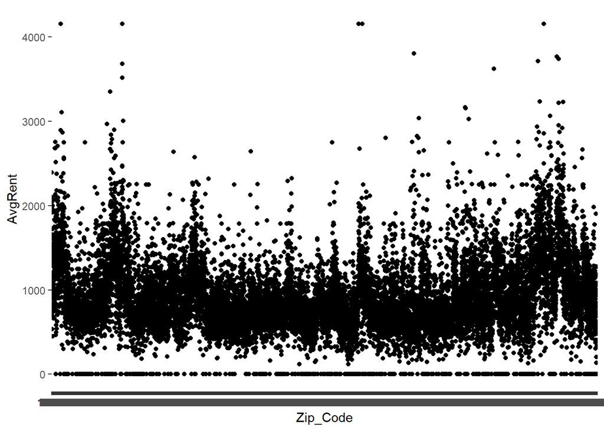

```r
ggplot(avg.rent.byzip, aes(x=Zip_Code, y=AvgRent)) + geom_point()
```

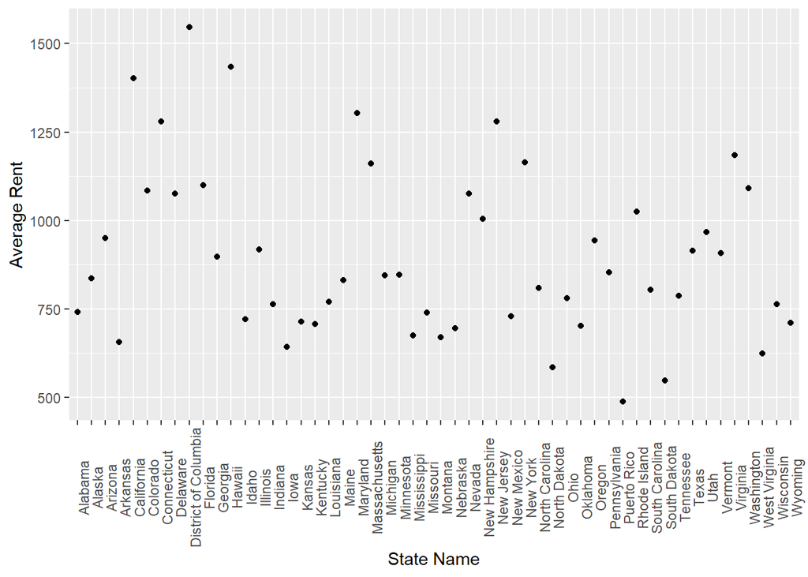

```r
ggplot(avg.rent.bystate, aes(x=avg.rent.bystate$State_Name,y=AvgRent)) + geom_point() + theme(axis.text.x = element_text(angle = 90)) + xlab("State Name") + ylab("Average Rent")
```